# R Notebook

Bibek Sapkota

# Vector Operators using R

task 1: Create two vector a and b

```r
a <- 1:10
b <- 1:10
```

```r
class(a)
```

```
[1] "integer"
```

```r
class(b)
```

```
[1] "integer"
```

task 2: This is same as task-1

```r
c <- seq(1:10)
d <- as.integer(c(1, 2, 3, 4, 5, 6, 7, 8, 9,10))
```

```r
class(c)
```

```
[1] "integer"
```

```r
class(d)
```

```
[1] "integer"
```

task 3:Adding two vector

```r
(a+b)
```

```
 [1]  2  4  6  8 10 12 14 16 18 20
```

## Using () for printing the output

```r
y <- seq(1, 10, length.out= 5)
```

task 1: printing the expression

```r
(y <- seq(1, 10, length.out= 5))
```

```
[1]  1.00  3.25  5.50  7.75 10.00
```

## Vector Operation using R

task 1: Multiplying two vector

```r
a <- 1:10
b <- 5

(a*b)
```

```
 [1]  5 10 15 20 25 30 35 40 45 50
```

```r
a <- 1:10
b <- 5
c <- c(2,3,4,5,6,7,8,9,10,11)

class(a)
```

```
[1] "integer"
```

```r
class(b)
```

```
[1] "numeric"
```

```r
class(c)
```

```
[1] "numeric"
```

## Blinding two column vector

```r
ac = cbind(a,c)
print(ac)
```

```
       a  c
 [1,]  1  2
 [2,]  2  3
 [3,]  3  4
 [4,]  4  5
 [5,]  5  6
 [6,]  6  7
 [7,]  7  8
 [8,]  8  9
 [9,]  9 10
[10,] 10 11
```

```r
acb <- ac * b
print(acb)
```

```
       a  c
 [1,]  5 10
 [2,] 10 15
 [3,] 15 20
 [4,] 20 25
 [5,] 25 30
 [6,] 30 35
 [7,] 35 40
 [8,] 40 45
 [9,] 45 50
[10,] 50 55
```

```r
class(acb)
```

```
[1] "matrix" "array"
```

## Calculating mean

```r
d <- apply(acb, MARGIN = 1, FUN =mean)
print(d)
```

```
 [1]  7.5 12.5 17.5 22.5 27.5 32.5 37.5 42.5 47.5 52.5
```

```r
(acbd <- cbind(acb, d))
```

```
       a  c    d
 [1,]  5 10  7.5
 [2,] 10 15 12.5
 [3,] 15 20 17.5
 [4,] 20 25 22.5
 [5,] 25 30 27.5
 [6,] 30 35 32.5
 [7,] 35 40 37.5
 [8,] 40 45 42.5
 [9,] 45 50 47.5
[10,] 50 55 52.5
```

```r
class(acbd)
```

```
[1] "matrix" "array"
```

```r
summary(acbd)
```

```
       a               c               d
 Min.   : 5.00   Min.   :10.00   Min.   : 7.50
 1st Qu.:16.25   1st Qu.:21.25   1st Qu.:18.75
 Median :27.50   Median :32.50   Median :30.00
 Mean   :27.50   Mean   :32.50   Mean   :30.00
 3rd Qu.:38.75   3rd Qu.:43.75   3rd Qu.:41.25
 Max.   :50.00   Max.   :55.00   Max.   :52.50
```

## Vector Recycling

```r
a <- 1:10
b <- 1:5

(a+b)
```

```
 [1]  2  4  6  8 10  7  9 11 13 15
```

```r
a <- 1:10
b <- 1:7

(a+b)
```

```
 [1]  2  4  6  8 10 12 14  9 11 13
```

## Function in R

```r
best_practice <- c("Let", "the", "compiter", "do", "the", "work")

print_words <- function(sentence){
  print(sentence[1])
  print(sentence[2])
  print(sentence[3])
  print(sentence[4])
  print(sentence[5])
  print(sentence[6])
}

print_words(best_practice)
```

```
[1] "Let"
[1] "the"
[1] "compiter"
[1] "do"
[1] "the"
[1] "work"
```

```r
print_words(best_practice[-6])
```

```
[1] "Let"
[1] "the"
[1] "compiter"
[1] "do"
[1] "the"
[1] NA
```

## Deleting element from vector

```r
best_practice[-6]
```

```
[1] "Let"      "the"      "compiter" "do"       "the"
```

```r
best_practice <- c("Let", "the", "compiter", "do", "the", "work")

print_words <- function(sentence){
  for (word in sentence){
    print(word)
  }
}

print_words(best_practice)
```

```
[1] "Let"
[1] "the"
[1] "compiter"
[1] "do"
[1] "the"
[1] "work"
```

```r
print_words(best_practice[-6])
```

```
[1] "Let"
[1] "the"
[1] "compiter"
[1] "do"
[1] "the"
```

## Apply, lapply, sapply, vapply

task 1: apply

```r
a <- 1:10
b <- 10:20

df <- data.frame(cbind (a, b) )
```

```r
apply(df, MARGIN = 1, FUN = mean)
```

```
 [1]  5.5  6.5  7.5  8.5  9.5 10.5 11.5 12.5 13.5 14.5 10.5
```

task 2: lapply

```r
a <- 1:10

lapply(a, MARGIN=1, FUN= mean)
```

```
[[1]]
[1] 1

[[2]]
[1] 2

[[3]]
[1] 3

[[4]]
[1] 4

[[5]]
[1] 5

[[6]]
[1] 6

[[7]]
[1] 7

[[8]]
[1] 8

[[9]]
[1] 9

[[10]]
[1] 10
```

task 3:sapply

```r
sapply(a, MARGIN =1 , FUN= mean)
```

```
 [1]  1  2  3  4  5  6  7  8  9 10
```

task4:vapply

```r
data <- list(l1 = c(1, 2, 3, 4),
             l2 = c(5, 6, 7, 8))

vapply(data, max, double(1) )
```

```
l1 l2
 4  8
```

## Conditional Statements

```r
y <-10
if (y<20){
  x <- "Too Low"
}else{
  x <- "Too High"
}

print(x)
```

```
[1] "Too Low"
```

```r
temp <- 35

if (temp <= 0){
    "freezing"
}else if (temp <= 10){
  "cold"
}else if (temp <=20){
  "cool"
}else if (temp <=30){
  "warm"
}else{
  "hot"
}
```

```
[1] "hot"
```

# Exploring covid datasets

1. Create data frame with these two column vectors in R Studio x = 1:30 y = x^3

```r
x <- as.numeric(1:30)
y <- x^3

df <- data.frame(x,y)

str(df)
```

```
'data.frame':   30 obs. of  2 variables:
 $ x: num  1 2 3 4 5 6 7 8 9 10 ...
 $ y: num  1 8 27 64 125 216 343 512 729 1000 ...
```

2. Create plot of x and y variables in R Studio and interpret it carefully

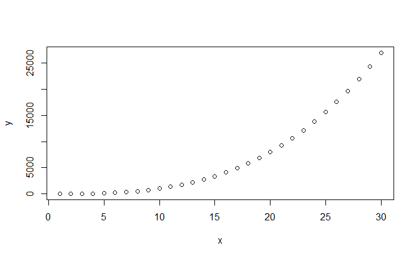

```r
plot(x,y)
```

3. Get appropriate correlation coefficient of this data in R Studio and interpret it carefully

```r
corr <- cor.test(x= df$x, y=df$y, method="spearman")
corr
```

```
    Spearman's rank correlation rho

data:  df$x and df$y
S = 0, p-value < 2.2e-16
alternative hypothesis: true rho is not equal to 0
sample estimates:
rho
  1
```

4. Transform the plot to linear using appropriate mathematical function in R Studio

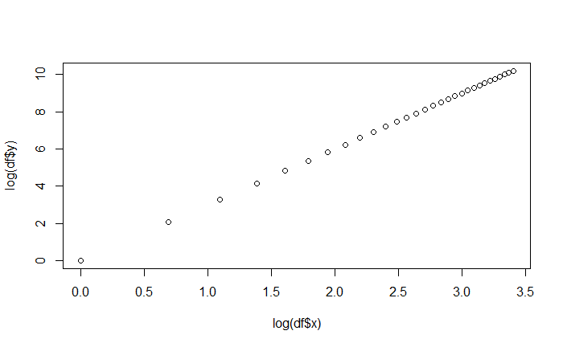

```r
plot(log(df$x), log(df$y))
```

6. Create a new column vector z defined in the slide 18 of session two slide deck in R Studio.

```r
z <- c(1, 1, 2, 2, 2, 2, 2, 3, 3, 3, 3, 3, 3, 3, 3, 3, 3, 3,  4, 4, 4, 4, 4, 5, 5, 5, 6, 6, 7)
```

7. Create a histogram of z variable in Rstudio and interpret it carefully

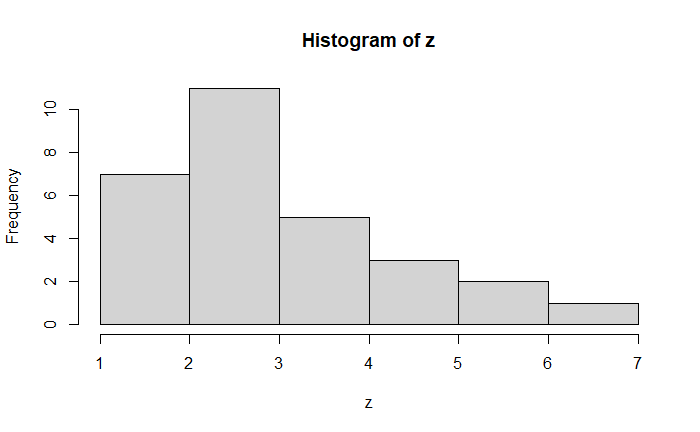

```r
hist(z)
```

8.Get summary statistics of z variable in R Studio and interpret it carefully

```r
summary(z)
```

```
   Min. 1st Qu.  Median    Mean 3rd Qu.    Max.
  1.000   3.000   3.000   3.414   4.000   7.000
```

9. Get box-plot of z variable in R Studio and interpret the result carefully

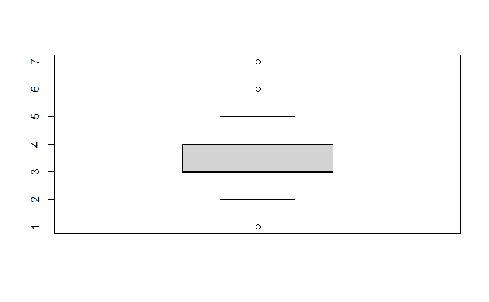

```r
boxplot(z)
```

10. Import “covnep_252days.csv” data in R Studio and describe the variables in it.

```r
packages_to_install <- c("readr")

for (package_name in packages_to_install) {
  if (!requireNamespace(package_name, quietly = TRUE)) {
    install.packages(package_name)
  }
}

library(readr)
```

```r
convnep_df <- read_csv("covnep_252days.csv", col_names = TRUE, col_types = cols(date = col_date(format = "%m/%d/%Y")))
str(convnep_df)
```

```
spc_tbl_ [252 × 7] (S3: spec_tbl_df/tbl_df/tbl/data.frame)
 $ date           : Date[1:252], format: "2020-01-23" "2020-01-24" "2020-01-25" ...
 $ totalCases     : num [1:252] 1 0 0 0 0 0 0 0 0 0 ...
 $ newCases       : num [1:252] 1 0 0 0 0 0 0 0 0 0 ...
 $ totalRecoveries: num [1:252] 0 0 0 0 0 0 0 0 1 1 ...
 $ newRecoveries  : num [1:252] 0 0 0 0 0 0 0 0 1 0 ...
 $ totalDeaths    : num [1:252] 0 0 0 0 0 0 0 0 0 0 ...
 $ newDeaths      : num [1:252] 0 0 0 0 0 0 0 0 0 0 ...
 - attr(*, "spec")=
  .. cols(
  ..   date = col_date(format = "%m/%d/%Y"),
  ..   totalCases = col_double(),
  ..   newCases = col_double(),
  ..   totalRecoveries = col_double(),
  ..   newRecoveries = col_double(),
  ..   totalDeaths = col_double(),
  ..   newDeaths = col_double()
  .. )
 - attr(*, "problems")=<externalptr>
```

11. Create a chart with “totalCases” variable in y-axis and “date” variable in the x-axis in R Studio, describe the process leading to the creation of this chart.

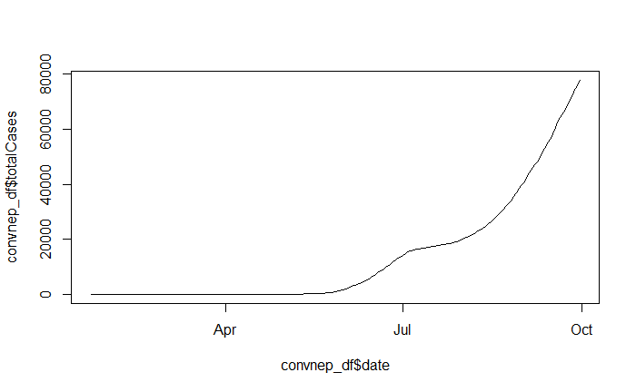

```r
plot(convnep_df$date, convnep_df$totalCases, type='l')
```

12. Get summary statistics of “totalCases” variable in R Studio and interpret it carefully

```r
summary(convnep_df$totalCases)
```

```
   Min. 1st Qu.  Median    Mean 3rd Qu.    Max.
      0       2     963   13376   19341   77816
```

13. Create histogram of “newCases” variable in R Studio and interpret it carefully.

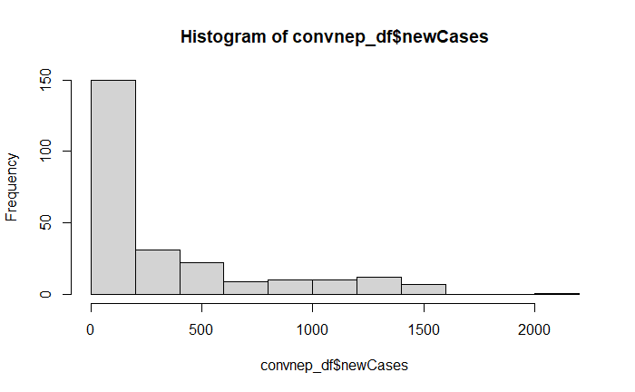

```r
hist(convnep_df$newCases)
```

14. Get summary statistics of “newCases” variable in R Studio and interpret it carefully.

```r
summary(convnep_df$newCases)
```

```
   Min. 1st Qu.  Median    Mean 3rd Qu.    Max.
    0.0     0.0    82.5   308.8   463.2  2020.0
```

15. Get “box and whisker” plot of “newCases” variable in R Studio and interpret it carefully.

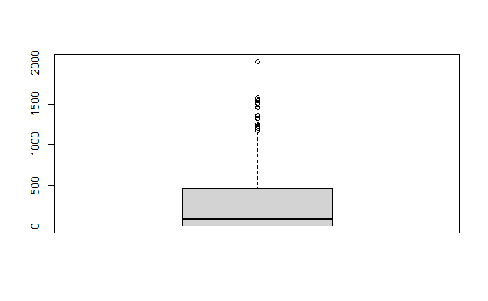

```r
boxplot(convnep_df$newCases)
```

16. Import “SAQ8.sav” data in R Studio and get frequency distribution (number and percentage of the attributes) of q01, q03, q06 and q08 variables on R Studio and interpret them carefully.

```r
packages_to_install <- c("haven")

for (package_name in packages_to_install) {
  if (!requireNamespace(package_name, quietly = TRUE)) {
    install.packages(package_name)
  }
}

library(haven)
```

```r
saq8_df <- read_sav("SAQ8.sav")

str(saq8_df)
```

```
tibble [2,571 × 8] (S3: tbl_df/tbl/data.frame)
 $ q01: dbl+lbl [1:2571] 2, 1, 2, 3, 2, 2, 2, 2, 3, 2, 2, 2, 3, 2, 2, 3, 1, 2, 2, 2, 1, 3, 2, 1, 2, 2, 3, ...
   ..@ label      : chr "Statistics makes me cry"
   ..@ format.spss: chr "F1.0"
   ..@ labels     : Named num [1:6] 1 2 3 4 5 9
   .. ..- attr(*, "names")= chr [1:6] "Strongly agree" "Agree" "Neither" "Disagree" ...
 $ q02: dbl+lbl [1:2571] 1, 1, 3, 1, 1, 1, 3, 2, 3, 4, 1, 1, 1, 2, 2, 1, 2, 2, 3, 1, 2, 2, 1, 1, 1, 1, 2, ...
   ..@ label      : chr "My friends will think I'm stupid for not being able to cope with SPSS"
   ..@ format.spss: chr "F1.0"
   ..@ labels     : Named num [1:5] 1 2 3 4 5
   .. ..- attr(*, "names")= chr [1:5] "Strongly agree" "Agree" "Neither" "Disagree" ...
 $ q03: dbl+lbl [1:2571] 4, 4, 2, 1, 3, 3, 3, 3, 1, 4, 5, 3, 3, 1, 3, 2, 5, 3, 4, 1, 3, 2, 4, 2, 1, 3, 1, ...
   ..@ label      : chr "Standard deviations excite me"
   ..@ format.spss: chr "F1.0"
   ..@ labels     : Named num [1:5] 1 2 3 4 5
   .. ..- attr(*, "names")= chr [1:5] "Strongly agree" "Agree" "Neither" "Disagree" ...
 $ q04: dbl+lbl [1:2571] 2, 3, 2, 4, 2, 2, 2, 2, 4, 3, 2, 3, 4, 2, 4, 2, 2, 3, 2, 2, 2, 4, 4, 2, 4, 3, 3, ...
   ..@ label      : chr "I dream that Pearson is attacking me with correlation coefficients"
   ..@ format.spss: chr "F1.0"
   ..@ labels     : Named num [1:6] 1 2 3 4 5 9
   .. ..- attr(*, "names")= chr [1:6] "Strongly agree" "Agree" "Neither" "Disagree" ...
 $ q05: dbl+lbl [1:2571] 2, 2, 4, 3, 2, 4, 2, 2, 5, 2, 2, 4, 3, 2, 2, 2, 1, 3, 3, 3, 4, 4, 2, 2, 2, 2, 4, ...
   ..@ label      : chr "I don't understand statistics"
   ..@ format.spss: chr "F1.0"
   ..@ labels     : Named num [1:5] 1 2 3 4 5
   .. ..- attr(*, "names")= chr [1:5] "Strongly agree" "Agree" "Neither" "Disagree" ...
 $ q06: dbl+lbl [1:2571] 2, 2, 1, 3, 3, 4, 2, 2, 3, 1, 1, 3, 2, 2, 2, 2, 1, 4, 1, 4, 1, 5, 2, 1, 3, 1, 4, ...
   ..@ label      : chr "I have little experience of computers"
   ..@ format.spss: chr "F1.0"
   ..@ labels     : Named num [1:5] 1 2 3 4 5
   .. ..- attr(*, "names")= chr [1:5] "Strongly agree" "Agree" "Neither" "Disagree" ...
 $ q07: dbl+lbl [1:2571] 3, 2, 2, 4, 3, 4, 2, 2, 5, 2, 2, 3, 3, 3, 3, 2, 1, 3, 1, 4, 2, 5, 4, 1, 3, 4, 3, ...
   ..@ label      : chr "All computers hate me"
   ..@ format.spss: chr "F1.0"
   ..@ labels     : Named num [1:5] 1 2 3 4 5
   .. ..- attr(*, "names")= chr [1:5] "Strongly agree" "Agree" "Neither" "Disagree" ...
 $ q08: dbl+lbl [1:2571] 1, 2, 2, 2, 2, 2, 2, 2, 5, 2, 2, 1, 3, 2, 2, 2, 1, 2, 1, 1, 1, 2, 3, 2, 4, 2, 4, ...
   ..@ label      : chr "I have never been good at mathematics"
   ..@ format.spss: chr "F1.0"
   ..@ labels     : Named num [1:5] 1 2 3 4 5
   .. ..- attr(*, "names")= chr [1:5] "Strongly agree" "Agree" "Neither" "Disagree" ...
```

```r
head(saq8_df, 10)
```

| q01 | q02 | q03 | q04 | q05 | q06 | q07 | q08 |
| --- | --- | --- | --- | --- | --- | --- | --- |
| 2 | 1 | 4 | 2 | 2 | 2 | 3 | 1 |
| 1 | 1 | 4 | 3 | 2 | 2 | 2 | 2 |
| 2 | 3 | 2 | 2 | 4 | 1 | 2 | 2 |
| 3 | 1 | 1 | 4 | 3 | 3 | 4 | 2 |
| 2 | 1 | 3 | 2 | 2 | 3 | 3 | 2 |
| 2 | 1 | 3 | 2 | 4 | 4 | 4 | 2 |
| 2 | 3 | 3 | 2 | 2 | 2 | 2 | 2 |
| 2 | 2 | 3 | 2 | 2 | 2 | 2 | 2 |
| 3 | 3 | 1 | 4 | 5 | 3 | 5 | 5 |
| 2 | 4 | 4 | 3 | 2 | 1 | 2 | 2 |

```r
packages_to_install <- c("plyr")

for (package_name in packages_to_install) {
  if (!requireNamespace(package_name, quietly = TRUE)) {
    install.packages(package_name)
  }
}

library(plyr)
```

```r
# Define a function
col_list <- list("q01", "q03", "q06", "q08")

# Create a function frequency table
frequency_table <- function(df, col_list) {
  for(item in col_list) {
    new_df <- count(df, item)
    new_df$percentage <- round(new_df$freq / sum(new_df$freq) * 100, 2)
    new_df$cumulative_percentage <- cumsum(new_df$percentage)
    print(new_df)
  }
}

frequency_table(saq8_df, col_list)
```

| q01 | freq | percentage | cumulative_percentage |
| --- | --- | --- | --- |
| 1 | 270 | 10.50 | 10.50 |
| 2 | 1338 | 52.04 | 62.54 |
| 3 | 735 | 28.59 | 91.13 |
| 4 | 187 | 7.27 | 98.40 |
| 5 | 41 | 1.59 | 99.99 |

| q03 | freq | percentage | cumulative_percentage |
| --- | --- | --- | --- |
| 1 | 497 | 19.33 | 19.33 |
| 2 | 672 | 26.14 | 45.47 |
| 3 | 878 | 34.15 | 79.62 |
| 4 | 448 | 17.43 | 97.05 |
| 5 | 76 | 2.96 | 100.01 |

| q06 | freq | percentage | cumulative_percentage |
| --- | --- | --- | --- |
| 1 | 702 | 27.30 | 27.30 |
| 2 | 1127 | 43.84 | 71.14 |
| 3 | 344 | 13.38 | 84.52 |
| 4 | 252 | 9.80 | 94.32 |
| 5 | 146 | 5.68 | 100.00 |

| q08 | freq | percentage | cumulative_percentage |
| --- | --- | --- | --- |
| 1 | 383 | 14.90 | 14.90 |
| 2 | 1487 | 57.84 | 72.74 |
| 3 | 482 | 18.75 | 91.49 |
| 4 | 147 | 5.72 | 97.21 |
| 5 | 72 | 2.80 | 100.01 |

17. Import “MR_drugs.xls” data in R Studio and replicate multiple response frequency distribution as shown in the slide 35 of the session 2 slide deck.

```r
packages_to_install <- c("readxl")

for (package_name in packages_to_install) {
  if (!requireNamespace(package_name, quietly = TRUE)) {
    install.packages(package_name)
  }
}

library(readxl)
```

```r
drugs_df <- readxl::read_excel("MR_drugs.xls")

str(drugs_df)
```

```
tibble [972 × 27] (S3: tbl_df/tbl/data.frame)
 $ id    : num [1:972] 1001 1002 1003 1004 1005 ...
 $ sex   : num [1:972] 2 2 2 2 2 2 2 2 2 2 ...
 $ city  : num [1:972] 1 1 1 1 1 1 1 1 1 1 ...
 $ inco1 : num [1:972] 0 0 0 0 0 1 0 0 1 0 ...
 $ inco2 : num [1:972] 0 1 0 1 0 1 1 1 1 1 ...
 $ inco3 : num [1:972] 0 0 0 0 0 0 0 0 0 0 ...
 $ inco4 : num [1:972] 0 0 0 0 0 0 0 0 0 0 ...
 $ inco5 : num [1:972] 0 0 0 0 0 0 0 0 0 0 ...
 $ inco6 : num [1:972] 1 0 1 0 0 0 0 0 0 0 ...
 $ inco7 : num [1:972] 0 0 0 0 1 0 0 0 0 0 ...
 $ pinco1: num [1:972] 6 2 6 2 7 2 2 2 2 2 ...
 $ pinco2: num [1:972] -1 -1 -1 -1 -1 1 -1 -1 1 -1 ...
 $ pinco3: num [1:972] -1 -1 -1 -1 -1 -1 -1 -1 -1 -1 ...
 $ pinco4: num [1:972] -1 -1 -1 -1 -1 -1 -1 -1 -1 -1 ...
 $ pinco5: num [1:972] -1 -1 -1 -1 -1 -1 -1 -1 -1 -1 ...
 $ pinco6: num [1:972] -1 -1 -1 -1 -1 -1 -1 -1 -1 -1 ...
 $ sinco1: chr [1:972] "\"mischeln\"/begging" "public support (unemployment insurance, social benefits)" "\"mischeln\"/begging" "public support (unemployment insurance, social benefits)" ...
 $ sinco2: chr [1:972] NA NA NA NA ...
 $ sinco3: chr [1:972] NA NA NA NA ...
 $ sinco4: chr [1:972] NA NA NA NA ...
 $ sinco5: chr [1:972] NA NA NA NA ...
 $ sinco6: chr [1:972] NA NA NA NA ...
 $ crime1: num [1:972] 0 0 0 0 0 3 0 0 0 0 ...
 $ crime2: num [1:972] 0 0 0 0 0 1 0 0 0 0 ...
 $ crime3: num [1:972] 0 0 0 0 0 0 0 0 0 0 ...
 $ crime4: num [1:972] 0 2 0 0 0 1 0 0 0 0 ...
 $ crime5: num [1:972] 0 0 0 0 0 0 0 0 0 0 ...
```

```r
head(drugs_df, 10)
```

| id | sex | city | inco1 | inco2 | inco3 | inco4 | inco5 | inco6 | inco7 | pinco1 | pinco2 | pinco3 | pinco4 | pinco5 | pinco6 | sinco1 | sinco2 | sinco3 | sinco4 | sinco5 | sinco6 | crime1 | crime2 | crime3 | crime4 | crime5 |
| --- | --- | --- | --- | --- | --- | --- | --- | --- | --- | --- | --- | --- | --- | --- | --- | --- | --- | --- | --- | --- | --- | --- | --- | --- | --- | --- |
| 1001 | 2 | 1 | 0 | 0 | 0 | 0 | 0 | 1 | 0 | 6 | -1 | -1 | -1 | -1 | -1 | "mischeln"/begging | NA | NA | NA | NA | NA | 0 | 0 | 0 | 0 | 0 |
| 1002 | 2 | 1 | 0 | 1 | 0 | 0 | 0 | 0 | 0 | 2 | -1 | -1 | -1 | -1 | -1 | public support (unemployment insurance, social benefits) | NA | NA | NA | NA | NA | 0 | 0 | 0 | 2 | 0 |
| 1003 | 2 | 1 | 0 | 0 | 0 | 0 | 0 | 1 | 0 | 6 | -1 | -1 | -1 | -1 | -1 | "mischeln"/begging | NA | NA | NA | NA | NA | 0 | 0 | 0 | 0 | 0 |
| 1004 | 2 | 1 | 0 | 1 | 0 | 0 | 0 | 0 | 0 | 2 | -1 | -1 | -1 | -1 | -1 | public support (unemployment insurance, social benefits) | NA | NA | NA | NA | NA | 0 | 0 | 0 | 0 | 0 |
| 1005 | 2 | 1 | 0 | 0 | 0 | 0 | 0 | 0 | 1 | 7 | -1 | -1 | -1 | -1 | -1 | legal occupation | NA | NA | NA | NA | NA | 0 | 0 | 0 | 0 | 0 |
| 1006 | 2 | 1 | 1 | 1 | 0 | 0 | 0 | 0 | 0 | 2 | 1 | -1 | -1 | -1 | -1 | public support (unemployment insurance, social benefits) | private support (partner, family, friends) | NA | NA | NA | NA | 3 | 1 | 0 | 1 | 0 |
| 1007 | 2 | 1 | 0 | 1 | 0 | 0 | 0 | 0 | 0 | 2 | -1 | -1 | -1 | -1 | -1 | public support (unemployment insurance, social benefits) | NA | NA | NA | NA | NA | 0 | 0 | 0 | 0 | 0 |
| 1008 | 2 | 1 | 0 | 1 | 0 | 0 | 0 | 0 | 0 | 2 | -1 | -1 | -1 | -1 | -1 | public support (unemployment insurance, social benefits) | NA | NA | NA | NA | NA | 0 | 0 | 0 | 0 | 0 |
| 1009 | 2 | 1 | 1 | 1 | 0 | 0 | 0 | 0 | 0 | 2 | 1 | -1 | -1 | -1 | -1 | public support (unemployment insurance, social benefits) | private support (partner, family, friends) | NA | NA | NA | NA | 0 | 0 | 0 | 0 | 0 |
| 1010 | 2 | 1 | 0 | 1 | 0 | 0 | 0 | 0 | 0 | 2 | -1 | -1 | -1 | -1 | -1 | public support (unemployment insurance, social benefits) | NA | NA | NA | NA | NA | 0 | 0 | 0 | 0 | 0 |

```r
mr_drugs_df <- data.frame(
  N = colSums(drugs_df[4:10]),
  Percent = round(colSums(drugs_df[4:10]) / sum(drugs_df[4:10]) * 100, 2),
  "Percent of Cases" = round(colSums(drugs_df[4:10]) / nrow(drugs_df[4:10]) * 100, 2)
)

print(mr_drugs_df)
```

|  | N | Percent | Percent.of.Cases |
| --- | --- | --- | --- |
| inco1 | 226 | 12.83 | 23.25 |
| inco2 | 607 | 34.47 | 62.45 |
| inco3 | 293 | 16.64 | 30.14 |
| inco4 | 50 | 2.84 | 5.14 |
| inco5 | 82 | 4.66 | 8.44 |
| inco6 | 151 | 8.57 | 15.53 |
| inco7 | 352 | 19.99 | 36.21 |

```r
# summary table as in spss
# import library for table

packages_to_install <- c("gt")

for (package_name in packages_to_install) {
  if (!requireNamespace(package_name, quietly = TRUE)) {
    install.packages(package_name)
  }
}

library(gt)
```

```r
# create table
mr_drugs_df %>%
  gt()%>%
  tab_header(
    title="$Income Frequencies"
  ) %>%
  tab_spanner(label="Responses", columns = c(N, Percent))
```

$Income Frequencies

[output not shown]

```r
#summary_rows(
 #   columns = everything(),
  #  fns = list(Total = ~mean(.))
  #)
```

#Pipe Operators

1. Initialize a vector

```r
packages_to_install <- c("magrittr")

for (package_name in packages_to_install) {
  if (!requireNamespace(package_name, quietly = TRUE)) {
    install.packages(package_name)
  }
}

library(magrittr)

x <-c (0.109, 0.359, 0.63, 0.996, 0.515, 0.142, 0.017, 0.829, 0.907)

# Compute the logarithm of `x`,
# return suitably lagged and iterated differences
# compute the exponential function and round the result
round(exp(diff(log(x))), 1)
```

```
[1]  3.3  1.8  1.6  0.5  0.3  0.1 48.8  1.1
```

2. Using pipe operator

```r
x %>%
  log() %>%
  diff() %>%
  exp() %>%
  round(1)
```

```
[1]  3.3  1.8  1.6  0.5  0.3  0.1 48.8  1.1
```

## Different pipe operators

```r
#Other pipe operators 1
x <- rnorm(100)

(x %<>% abs %>% sort)
```

```
  [1] 0.01687390 0.02684709 0.04507040 0.05075958 0.07734798 0.12250368 0.12632598 0.14382316 0.17657710
 [10] 0.18580895 0.20339400 0.21685111 0.22416717 0.23557482 0.23608068 0.27286675 0.28353937 0.29012440
 [19] 0.31123185 0.31369356 0.31415409 0.33088265 0.33542333 0.33875663 0.33879214 0.34203605 0.36451668
 [28] 0.37549615 0.38768393 0.38939577 0.39648546 0.42450513 0.43365466 0.43446258 0.46403534 0.46439417
 [37] 0.48293769 0.48639127 0.48931287 0.53475322 0.54777161 0.56512902 0.57419881 0.57612537 0.57786445
 [46] 0.57919634 0.58284964 0.58335923 0.62276135 0.63811391 0.66730679 0.69087196 0.69970742 0.70317481
 [55] 0.72384406 0.72766655 0.73288806 0.76122067 0.78708101 0.80633600 0.81901897 0.83500717 0.84237617
 [64] 0.84904371 0.85018561 0.85346022 0.88977773 0.96684805 1.00260119 1.04816506 1.05827471 1.09011203
 [73] 1.09755697 1.13566691 1.14052686 1.15492245 1.15890837 1.16899077 1.17374979 1.22949280 1.25267353
 [82] 1.28368268 1.30529507 1.30580269 1.33465880 1.34580215 1.38981521 1.43100277 1.50739485 1.52970043
 [91] 1.60282707 1.63431359 1.63848553 1.65091490 1.87924285 2.07438707 2.11635992 2.63070047 2.63255902
[100] 2.80338031
```

```
[1] 11.685398  6.175457
```

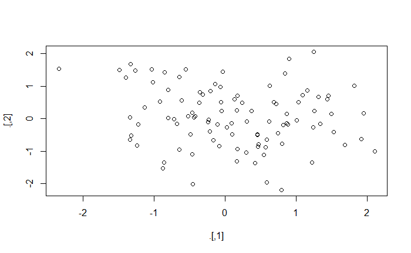

```r
#Other pipe operators 2
rnorm(200) %>%
  matrix(ncol = 2) %T>%
  plot %>%
  colSums
```

```
[1]  3.937396 -3.433309
```

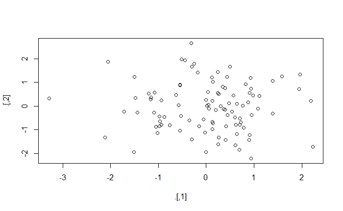

```r
#Other pipe operators 2
rnorm(200) %>%
  matrix(ncol = 2) %T>%
  plot %>%
  colSums
```

```
[1]   9.870679 -11.989906
```

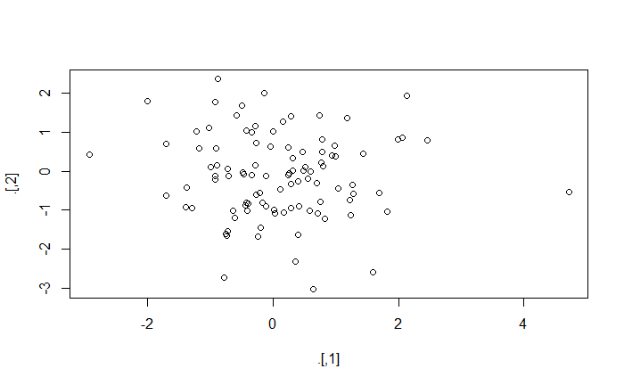

```r
#The above code is a shortcut for this code:
rnorm(200) %>%
  matrix(ncol = 2) %T>%
  { plot(.); . } %>%
  colSums
```

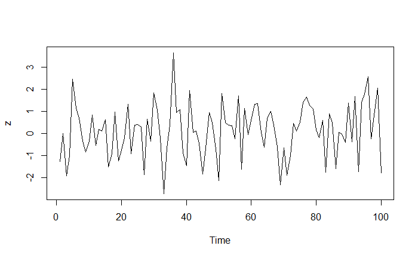

```r
#Other pipe operator 3
data.frame(z = rnorm(100)) %$%
  ts.plot(z)
```

```r
#More examples:
#Load the package, install if require!
packages_to_install <- c("babynames")

for (package_name in packages_to_install) {
  if (!requireNamespace(package_name, quietly = TRUE)) {
    install.packages(package_name)
  }
}

library(babynames)
library(dplyr)
```

```r
data("babynames")
```

```r
sum(select(filter(babynames,sex=="M",name=="Taylor"),n))
```

```
[1] 109852
```

```r
# Do the same but now with `%>%`
babynames%>%filter(sex=="M",name=="Taylor")%>%
  select(n)%>%
  sum
```

```
[1] 109852
```

```r
#Assigning new variable and using compound assignment pipe operator:
# Load in the Iris data
iris <- read.csv(url("http://archive.ics.uci.edu/ml/machine-learning-databases/iris/iris.data"), header = FALSE)
```

```r
# Add column names to the Iris data
names(iris) <- c("Sepal.Length", "Sepal.Width", "Petal.Length", "Petal.Width", "Species")
```

```r
# Compute the square root of `iris$Sepal.Length` and assign it to the new variable
iris$Sepal.Length.SQRT <-
  iris$Sepal.Length %>%
  sqrt()
```

```r
#Compound pipe operator:
# Compute the square root of `iris$Sepal.Length` and assign it to the same variable
iris$Sepal.Length %<>% sqrt
```

```
[1]   9.040591 -10.754680
```

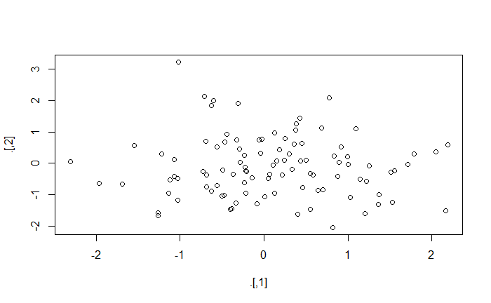

```r
#The tee operator:
set.seed(123)
rnorm(200) %>%
  matrix(ncol = 2) %T>%
  plot %>%
  colSums
```

```r
#Exposing pipe operator: comes handy when "data" argument is not needed in a function
iris %>%
  subset(Sepal.Length > mean(Sepal.Length)) %$%
  cor(Sepal.Length, Sepal.Width)
```

```
[1] 0.3365679
```

## dplyr Package in R

```r
#install.packages("hflights")
packages_to_install <- c("hflights")

for (package_name in packages_to_install) {
  if (!requireNamespace(package_name, quietly = TRUE)) {
    install.packages(package_name)
  }
}

library(hflights)
#Without pipe operators:
grouped_flights <- group_by(hflights, Year, Month, DayofMonth)
flights_data <- select(grouped_flights, Year:DayofMonth, ArrDelay, DepDelay)
summarized_flights <- summarise(flights_data,
                                arr = mean(ArrDelay, na.rm = TRUE),     #Remove missing data!
                                dep = mean(DepDelay, na.rm = TRUE))     #Remove missing data!
```

```r
final_result <- filter(summarized_flights, arr > 30 | dep > 30)
final_result
```

| Year | Month | DayofMonth | arr | dep |
| --- | --- | --- | --- | --- |
| 2011 | 2 | 4 | 44.08088 | 47.17216 |
| 2011 | 3 | 3 | 35.12898 | 38.20064 |
| 2011 | 3 | 14 | 46.63830 | 36.13657 |
| 2011 | 4 | 4 | 38.71651 | 27.94915 |
| 2011 | 4 | 25 | 37.79845 | 22.25574 |
| 2011 | 5 | 12 | 69.52046 | 64.52039 |
| 2011 | 5 | 20 | 37.02857 | 26.55090 |
| 2011 | 6 | 22 | 65.51852 | 62.30979 |
| 2011 | 7 | 29 | 29.55755 | 31.86944 |
| 2011 | 9 | 29 | 39.19649 | 32.49528 |

[output cut: 4 more lines]

```r
# With pipe operators:
hflights %>%
  group_by(Year, Month, DayofMonth) %>%
  select(Year:DayofMonth, ArrDelay, DepDelay) %>%
  summarise(arr = mean(ArrDelay, na.rm = TRUE), dep = mean(DepDelay, na.rm = TRUE)) %>%
  filter(arr > 30 | dep > 30)
```

| Year | Month | DayofMonth | arr | dep |
| --- | --- | --- | --- | --- |
| 2011 | 2 | 4 | 44.08088 | 47.17216 |
| 2011 | 3 | 3 | 35.12898 | 38.20064 |
| 2011 | 3 | 14 | 46.63830 | 36.13657 |
| 2011 | 4 | 4 | 38.71651 | 27.94915 |
| 2011 | 4 | 25 | 37.79845 | 22.25574 |
| 2011 | 5 | 12 | 69.52046 | 64.52039 |
| 2011 | 5 | 20 | 37.02857 | 26.55090 |
| 2011 | 6 | 22 | 65.51852 | 62.30979 |
| 2011 | 7 | 29 | 29.55755 | 31.86944 |
| 2011 | 9 | 29 | 39.19649 | 32.49528 |

[output cut: 4 more lines]

```r
#ARRNGE data with dplyr and pipe operators:
#Ascending order
iris %>%
  select(starts_with("Sepal")) %>%
  filter(Sepal.Length >=70) %>%
  arrange(Sepal.Length)     #Sort data in ascending order
```

| Sepal.Length | Sepal.Width | Sepal.Length.SQRT |
| --- | --- | --- |

```r
#Descending order:
iris %>%
  select(starts_with("Sepal")) %>%
  filter(Sepal.Length >=70) %>%
  arrange(desc(Sepal.Length))       #Sort data in descending order
```

| Sepal.Length | Sepal.Width | Sepal.Length.SQRT |
| --- | --- | --- |

```r
#MUTATE with dplyr and pipe operators:
iris %>%
  select(contains("Sepal")) %>%
  mutate(Sepal.Area = Sepal.Length * Sepal.Width)
```

| Sepal.Length | Sepal.Width | Sepal.Length.SQRT | Sepal.Area |
| --- | --- | --- | --- |
| 2.258318 | 3.5 | 2.258318 | 7.904113 |
| 2.213594 | 3.0 | 2.213594 | 6.640783 |
| 2.167948 | 3.2 | 2.167948 | 6.937435 |
| 2.144761 | 3.1 | 2.144761 | 6.648759 |
| 2.236068 | 3.6 | 2.236068 | 8.049845 |
| 2.323790 | 3.9 | 2.323790 | 9.062781 |
| 2.144761 | 3.4 | 2.144761 | 7.292188 |
| 2.236068 | 3.4 | 2.236068 | 7.602631 |
| 2.097618 | 2.9 | 2.097618 | 6.083091 |
| 2.213594 | 3.1 | 2.213594 | 6.862143 |

[output cut: 140 more lines]

```r
iris %>%
  select(ends_with("Length")) %>%
  mutate(Length.Diff = Sepal.Length - Petal.Length)
```

| Sepal.Length | Petal.Length | Length.Diff |
| --- | --- | --- |
| 2.258318 | 1.4 | 0.8583180 |
| 2.213594 | 1.4 | 0.8135944 |
| 2.167948 | 1.3 | 0.8679483 |
| 2.144761 | 1.5 | 0.6447611 |
| 2.236068 | 1.4 | 0.8360680 |
| 2.323790 | 1.7 | 0.6237900 |
| 2.144761 | 1.4 | 0.7447611 |
| 2.236068 | 1.5 | 0.7360680 |
| 2.097618 | 1.4 | 0.6976177 |
| 2.213594 | 1.5 | 0.7135944 |

[output cut: 140 more lines]

```r
iris %>%
  select(ends_with("Length"), Species) %>%
  rowwise() %>%
  mutate(Length.Diff = Sepal.Length - Petal.Length)
```

| Sepal.Length | Petal.Length | Species | Length.Diff |
| --- | --- | --- | --- |
| 2.258318 | 1.4 | Iris-setosa | 0.8583180 |
| 2.213594 | 1.4 | Iris-setosa | 0.8135944 |
| 2.167948 | 1.3 | Iris-setosa | 0.8679483 |
| 2.144761 | 1.5 | Iris-setosa | 0.6447611 |
| 2.236068 | 1.4 | Iris-setosa | 0.8360680 |
| 2.323790 | 1.7 | Iris-setosa | 0.6237900 |
| 2.144761 | 1.4 | Iris-setosa | 0.7447611 |
| 2.236068 | 1.5 | Iris-setosa | 0.7360680 |
| 2.097618 | 1.4 | Iris-setosa | 0.6976177 |
| 2.213594 | 1.5 | Iris-setosa | 0.7135944 |

[output cut: 140 more lines]

```r
iris %>%
  select(contains("Sepal"), Species) %>%
  transmute(Sepal.Area = Sepal.Length * Sepal.Width)
```

| Sepal.Area |
| --- |
| 7.904113 |
| 6.640783 |
| 6.937435 |
| 6.648759 |
| 8.049845 |
| 9.062781 |
| 7.292188 |
| 7.602631 |
| 6.083091 |
| 6.862143 |

[output cut: 140 more lines]

```r
NA
```

## We must use R markdown syntax R markdown with knitr and kable,

```r
knitr::kable(head(mtcars), digits = 2, align = c(rep("l", 4), rep("c", 4), rep("r", 4)))
```

|  | mpg | cyl | disp | hp | drat | wt | qsec | vs | am | gear | carb |
| --- | --- | --- | --- | --- | --- | --- | --- | --- | --- | --- | --- |
| Mazda RX4 | 21.0 | 6 | 160 | 110 | 3.90 | 2.62 | 16.46 | 0 | 1 | 4 | 4 |
| Mazda RX4 Wag | 21.0 | 6 | 160 | 110 | 3.90 | 2.88 | 17.02 | 0 | 1 | 4 | 4 |
| Datsun 710 | 22.8 | 4 | 108 | 93 | 3.85 | 2.32 | 18.61 | 1 | 1 | 4 | 1 |
| Hornet 4 Drive | 21.4 | 6 | 258 | 110 | 3.08 | 3.21 | 19.44 | 1 | 0 | 3 | 1 |
| Hornet Sportabout | 18.7 | 8 | 360 | 175 | 3.15 | 3.44 | 17.02 | 0 | 0 | 3 | 2 |
| Valiant | 18.1 | 6 | 225 | 105 | 2.76 | 3.46 | 20.22 | 1 | 0 | 3 | 1 |

```r
packages_to_install <- c("xtable")

for (package_name in packages_to_install) {
  if (!requireNamespace(package_name, quietly = TRUE)) {
    install.packages(package_name)
  }
}

library(xtable)
```

```r
print(xtable(head(mtcars)), type = 'html')
```

[output not shown]

# Packages in R

1. Install and import dplyr,rjson package

```r
packages_to_install <- c("dplyr", "rjson")

for (package_name in packages_to_install) {
  if (!requireNamespace(package_name, quietly = TRUE)) {
    install.packages(package_name)
  }
}

library(dplyr)
library(rjson)
```

2. Help on any install pacakage

```r
#help(rjson)
#or
#?rjson
```

3. Using the rjson library to read content from json file

```r
data <- fromJSON(file="jason_data.json")
print(data)
```

[output not shown]

4. Convert to dataframe

```r
jason_data_frame <- as.data.frame(data)
print(jason_data_frame)
```

[output not shown]

```r
jason_data_frame$Salary <- as.numeric(jason_data_frame$Salary)
summary(jason_data_frame$Salary)
```

[output not shown]

```r
hist(jason_data_frame$Salary)
```

[output not shown]